# Tutorial 6: REDUCE

Harmen Bussemaker and Vincent FitzPatrick

Saturday, June 27, 2015

# REDUCE: Identifying sequence drivers of gene expression with linear modeling

In this part of the assignment, we will use all genes in `alpha`, not just the high-variance genes.

1. Load “alpha.rda” and “hexamerCounts.RData”. Find the `universe` of ORFs that are shared between `alpha` and `hexamerCounts`. How many are there? Then filter both matrices to include only these genes.

```r
load("alpha.rda")
load("hexamerCounts.RData")
universe = intersect(rownames(alpha),rownames(hexamerCounts))

alpha = alpha[universe,]
hexamerCounts = hexamerCounts[universe,]
```

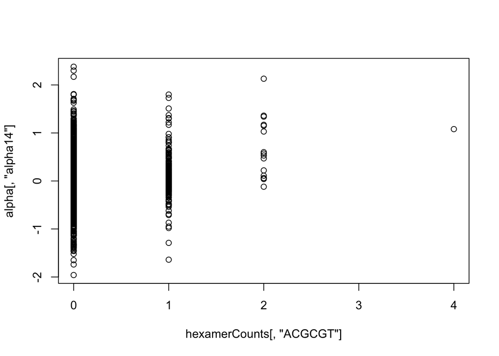

```r
plot(hexamerCounts[,"ACGCGT"],alpha[,"alpha14"])
```

**There appears to be a positive correlation between hexamer count and alpha14 expression levels.**

3. Make a `boxplot()` showing the same data. What extra information does a boxplot tell you?

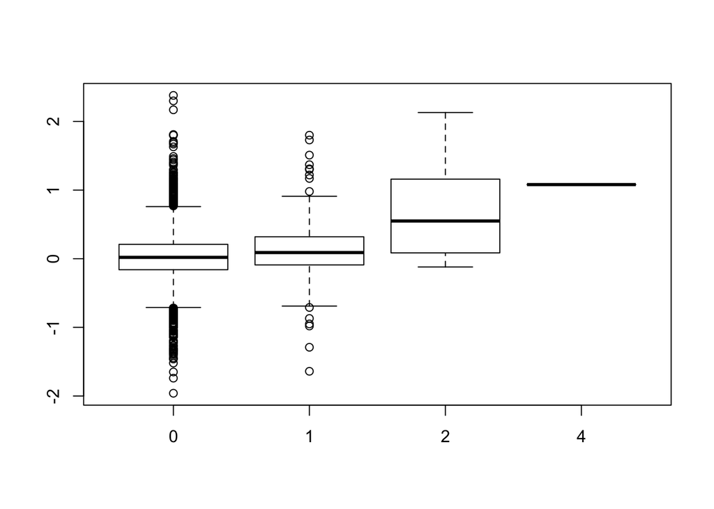

```r
boxplot(alpha[,"alpha14"] ~ hexamerCounts[,"ACGCGT"])
```

4. Use `cor.test` to compute the Pearson correlation between the two variables. What is the value of this correlation? Is it positive or negative? Is the correlation significant?

```r
test = cor.test(hexamerCounts[,"ACGCGT"], alpha[,"alpha14"])
test$estimate #Pearson correlation, positive
```

```
##       cor
## 0.1010617
```

```r
test$p.value #p-value, highly significant
```

```
## [1] 7.105427e-15
```

5. Now use `cor` instead of `cor.test` to compute the same correlation coefficient (hint: you can change how missing values are dealt with using the `use` option; see documentation for `cor`). Do you get exactly the same value as with `cor.test`?

```r
cor(hexamerCounts[,"ACGCGT"],alpha[,"alpha14"],use = "pairwise.complete.obs")
```

```
## [1] 0.1010617
```

**`pairwise.complete.obs` includes pairs of values for which neither array has NA. It gives the same value.**

6. Next, perform a linear regression of the expression log-ratio on the motif count for the same data using `lm(logratio ~ count)`. Store the result in a variable named `fit`. You can use `summary(fit)` to get a lot of information about the fit. What is the value of the regression coefficient (“slope”)? Is it the same as the Pearson correlation?

```r
fit = lm(alpha[,"alpha14"] ~ hexamerCounts[,"ACGCGT"])
summary(fit)
```

```
##
## Call:
## lm(formula = alpha[, "alpha14"] ~ hexamerCounts[, "ACGCGT"])
##
## Residuals:
##      Min       1Q   Median       3Q      Max
## -1.97915 -0.17915  0.00085  0.19085  2.36085
##
## Coefficients:
##                           Estimate Std. Error t value Pr(>|t|)
## (Intercept)               0.019147   0.004765   4.018 5.94e-05 ***
## hexamerCounts[, "ACGCGT"] 0.163615   0.020966   7.804 7.05e-15 ***
## ---
## Signif. codes:  0 '***' 0.001 '**' 0.01 '*' 0.05 '.' 0.1 ' ' 1
##
## Residual standard error: 0.3592 on 5902 degrees of freedom
##   (87 observations deleted due to missingness)
## Multiple R-squared:  0.01021,    Adjusted R-squared:  0.01005
## F-statistic:  60.9 on 1 and 5902 DF,  p-value: 7.048e-15
```

```r
fit$coefficients[2]
```

```
## hexamerCounts[, "ACGCGT"]
##                 0.1636148
```

```r
test$estimate
```

```
##       cor
## 0.1010617
```

**The values are not the same, but they do have the same sign.**

7. An exact relationship $\beta = (\sigma_y/\sigma_x)r$ holds between the slope $\beta$ and the Pearson correlation coefficient $r$; here $\sigma_x$ and $\sigma_y$ are the standard deviation of the independent and dependent variable, respectively. Check explicitly that this relationship also hold for the present data.

```r
test$estimate*sd(alpha[,"alpha14"],na.rm = T)/sd(hexamerCounts[,"ACGCGT"])
```

```
##       cor
## 0.1629587
```

```r
test$estimate*sd(alpha[,"alpha14"],na.rm = T)/sd(hexamerCounts[!is.na(alpha[,"alpha14"]),"ACGCGT"])
```

```
##       cor
## 0.1636148
```

8. We are now going to infer the protein-level (differential) activity of Mbp1/Swi6 over the time course. To this end, use `cor()` to compute the Pearson correlation between the logratios at each time point and the count for ACGCGT (hint: you might want to use “pairwise.complete.obs”). Plot this correlation as a function of time, and add a horizontal line at cor = 0. What do you observe?

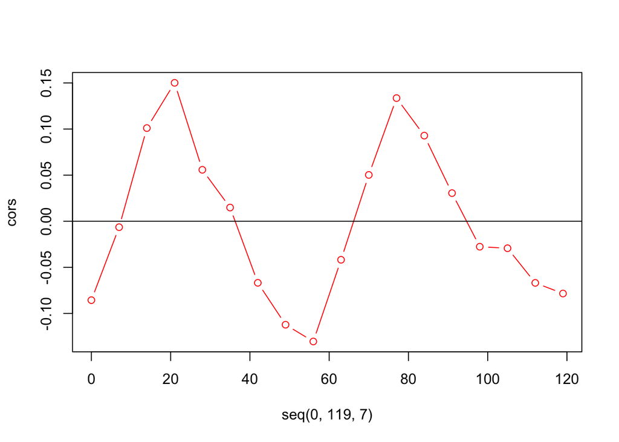

```r
cors = cor(alpha, hexamerCounts[,"ACGCGT"],use = "pairwise.complete.obs")
plot(seq(0,119,7),cors,type="b",col="red")
abline(h=0)
```

**The correlation between expression and hexamer count oscilates between negative and positive over the course of the cell cycle. This suggests that this hexamer acts as a binding site for a factor or factors that induce expression at some points and repress expression at others.**

9. Finally, you are going to do some motif discovery a la REDUCE (Bussemaker *et al.*, 2001; http://www.ncbi.nlm.nih.gov/pubmed/9843569). For the 14 minute expression profile, determine which hexamer has the strongest positive correlation with the expression log-ratios at 14min. Which motif is this? List the 10 top motifs. Do you see relationships between the top 10 motifs?

```r
cors2 = cor(hexamerCounts,use = "pairwise.complete.obs",alpha[,"alpha14"])
colnames(hexamerCounts)[which.max(cors2)]
```

```
## [1] "ACGCGT"
```

```r
colnames(hexamerCounts)[order(cors2,decreasing = T)][1:10]
```

```
##  [1] "ACGCGT" "GACGCG" "AAGGGG" "GGGGCC" "AAAAGG" "CCCACG" "GCGTAG"
##  [8] "GTTTCC" "ATAAGG" "TGTAAT"
```

**Sevaral of the motifs apper to be overlapping patterns of the first hexamer (ACGCGT, gACGCG, GCGTag).**

10. Which motif shown the strongest *negative* correlation with the same expression data? Make a plot for the inferred activity of this motif as a function of time, and add to it the result for ACGCGT obtained above, using a different color. Add a legend to the plot that defines which motif is used for each line.

```r
colnames(hexamerCounts)[which.min(cors2)]
```

```
## [1] "GATGAG"
```

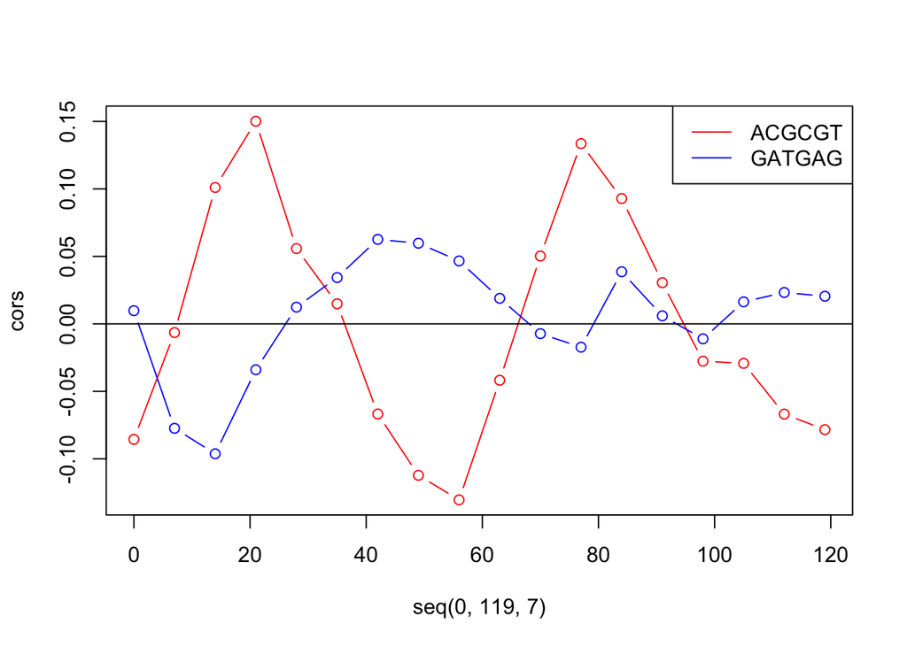

```r
cors3 = cor(alpha,hexamerCounts[,"GATGAG"],use = "complete.obs")

plot(seq(0,119,7),cors,type="b",col="red")
points(seq(0,119,7),cors3,type="b",col="blue")
legend("topright",legend = c("ACGCGT","GATGAG"),lwd=1,col=c("red","blue"))
abline(h=0)
```